# aer13_FinalHomeworkCode_04

Abby_Robinson

10/20/2021

#What’s Your Malfunction?

##[1] Write a simple R function, Z.prop.test(), that can perform one- or two-sample Z-tests for proportion data

Function for z test

```r
#p1 = estimated proportion based on sample
#n1 = estimated sample size based on sample

#p2 = estimated proportion based on second sample (if two-sample test)
#n2 = estimated sample size based on second sample (if two-sample test)

#p = (no default) as the expected value for the population proportion

Z.prop.test = function(p1, n1, p, p2, n2){

if(is.null(p2)){

one.tail.p <- NULL

rule_one <- (n1*p1)

rule_two <- (n1*(1-p1))

Z <- (p1-p)/sqrt((p*(1-p))/n1)

one.tail.p <- round(pnorm(abs(Z),lower.tail = FALSE),3)

CI <- p1+c(-1,1)*qnorm(0.975)*sqrt(p1*(1-p1)/n1)

p.value <- pnorm(-abs(Z))

cat("Rule One =", rule_one <- rule_one, "\n",
    "Rule Two =", rule_two <- rule_two, "\n",
    "Z_score =", Z <- Z, "\n",
    "one_tailed =", one.tail.p <- one.tail.p, "\n",
    "one_tailed_p_value =", p.value <- p.value, "\n",
    "two_tailed =", 2*one.tail.p, "\n",
    "two-tailed_p_value =", 2*p.value, "\n",
    "CI =", CI <- CI, "\n")

} else {

Z.two.sample <- (p1-p2)/ sqrt((p*(1-p))*((1/n1)+(1/n2)))

CI.two.sample <- CI <- p2+c(-1,1)*qnorm(0.975)*sqrt(p2*(1-p2)/n2)

P.Value <- pnorm(-Z.two.sample)

cat( "Z_score =", Z.two.sample <- Z.two.sample, "\n",
     "CI =", CI.two.sample <- CI.two.sample, "\n",
     "P-Value =", P.Value <- P.Value, "\n")
}

}
```

Run one sample z test

```r
Z.prop.test(0.276, 29, 0.5,p2=NULL, 0)
```

```
## Rule One = 8.004
##  Rule Two = 20.996
##  Z_score = -2.412554
##  one_tailed = 0.008
##  one_tailed_p_value = 0.007920599
##  two_tailed = 0.016
##  two-tailed_p_value = 0.0158412
##  CI = 0.1133055 0.4386945
```

Run two sample

```r
Z.prop.test(0.276, 29, 0.5, 0.35, 35)
```

```
## Z_score = -0.5893927
##  CI = 0.1919827 0.5080173
##  P-Value = 0.7222011
```

[2] The dataset from Kamilar and Cooper has in it a large number of variables related to life history and body size. For this exercise, the end aim is to fit a simple linear regression model to predict longevity (MaxLongevity_m) measured in months from species’ brain size (Brain_Size_Species_Mean) measured in grams. Do the following for both longevity~brain size and log(longevity)~log(brain size)

load libraries

```r
library(curl)
```

```r
library(ggplot2)
library(gridExtra)
library(lmodel2)
```

load dataset

```r
f <- curl("https://raw.githubusercontent.com/fuzzyatelin/fuzzyatelin.github.io/master/AN588_Fall21/KamilarAndCooperData.csv")
data  <- read.csv(f, header = TRUE, sep = ",", stringsAsFactors = FALSE)
data
```

[output not shown]

[output cut: 2767 more lines]

linear regression model for longevity ~ brain size

```r
m <- lm(MaxLongevity_m ~ Brain_Size_Species_Mean, data = data)
m
```

```
##
## Call:
## lm(formula = MaxLongevity_m ~ Brain_Size_Species_Mean, data = data)
##
## Coefficients:
##             (Intercept)  Brain_Size_Species_Mean
##                 248.952                    1.218
```

use ggplot to graph data and use geom_point and geom_smooth to superimpose fitted line, use geom_text to append the equation using the intercept and slope from the above output

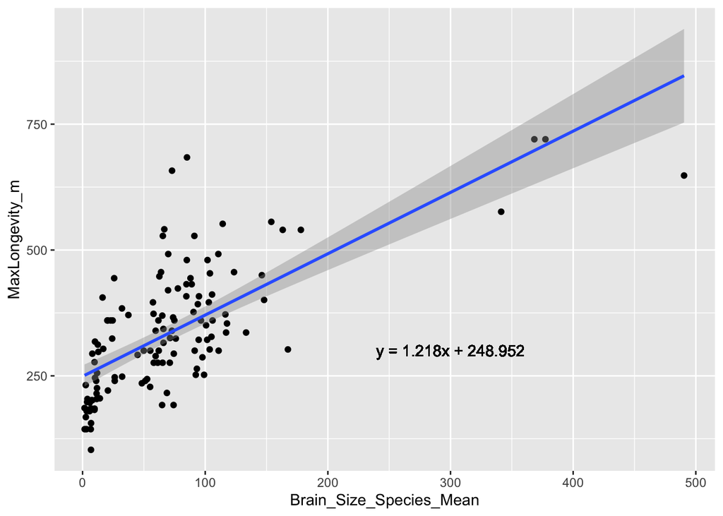

```r
g <- ggplot(data = data, aes(x = Brain_Size_Species_Mean, y = MaxLongevity_m))
g <- g + geom_point()
g <- g + geom_smooth(method = "lm", formula = y ~ x)
g <- g + geom_text(x=300, y = 300, label = " y = 1.218x + 248.952 ")
g
```

Alternative code that will also give the r-squared

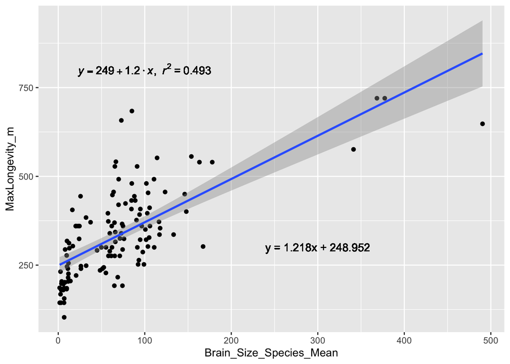

```r
df <- data.frame(x = data$Brain_Size_Species_Mean, y = data$MaxLongevity_m)
lm_eqn <- function(df){
    m <- lm(y ~ x, df);
    eq <- substitute(italic(y) == a + b %.% italic(x)*","~~italic(r)^2~"="~r2,
         list(a = format(unname(coef(m)[1]), digits = 2),
              b = format(unname(coef(m)[2]), digits = 2),
             r2 = format(summary(m)$r.squared, digits = 3)))
    as.character(as.expression(eq));
}

p1 <- g + geom_text(x = 100, y = 800, label = lm_eqn(df), parse = TRUE)
p1
```

linear regression model for log model

```r
longevity <- log(data$MaxLongevity_m)

brain.size <- log(data$Brain_Size_Species_Mean)

m2 <- lm(longevity ~ brain.size, data = data)
m2
```

```
##
## Call:
## lm(formula = longevity ~ brain.size, data = data)
##
## Coefficients:
## (Intercept)   brain.size
##      4.8790       0.2341
```

use ggplot to graph model data

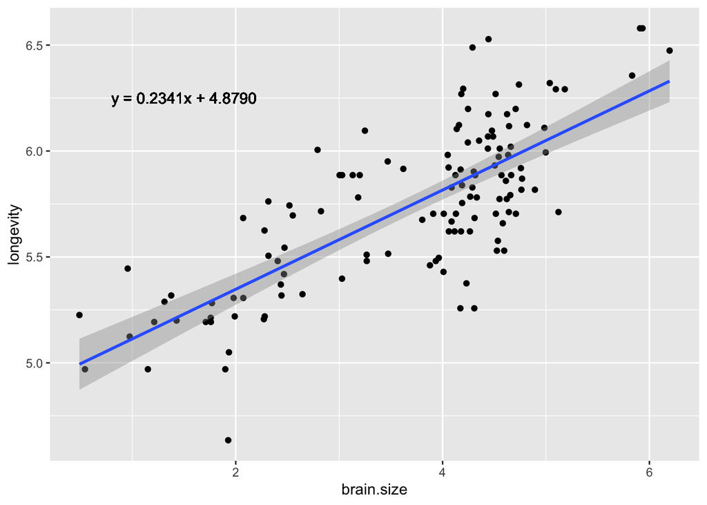

```r
g <- ggplot(data = data, aes(x = brain.size, y = longevity))
g <- g + geom_point()
g <- g + geom_smooth(method = "lm", formula = y ~ x)
g <- g + geom_text(x=1.5, y = 6.25, label = " y = 0.2341x + 4.8790 ")
g
```

Alternative code:

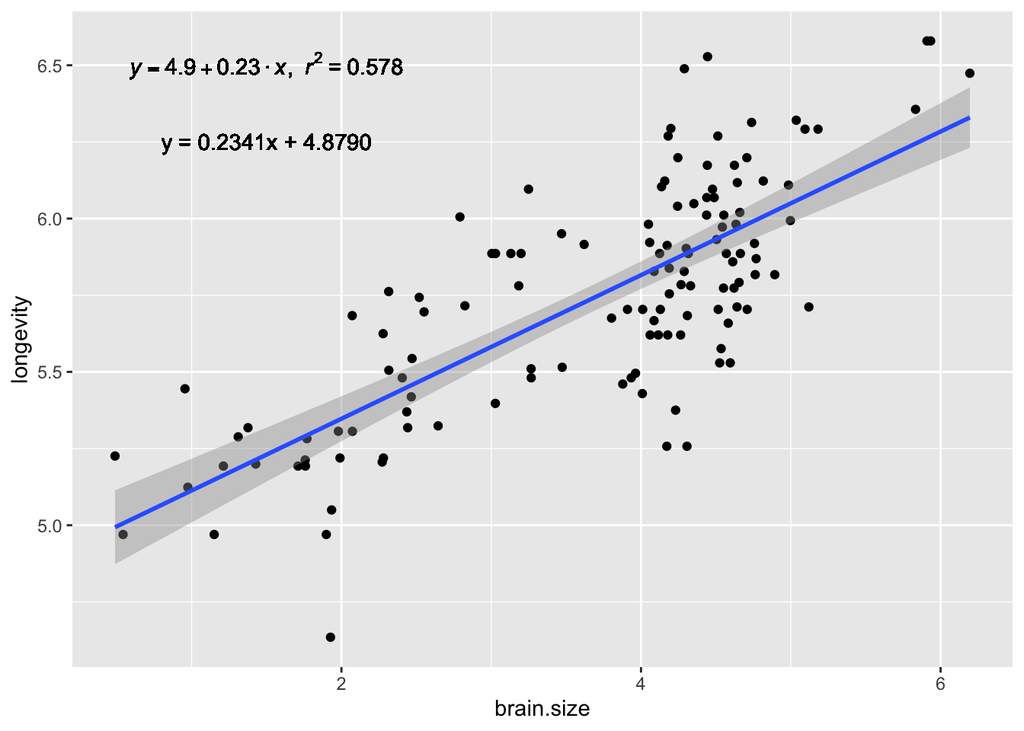

```r
df <- data.frame(x = brain.size, y = longevity)
lm_eqn <- function(df){
    m <- lm(y ~ x, df);
    eq <- substitute(italic(y) == a + b %.% italic(x)*","~~italic(r)^2~"="~r2,
         list(a = format(unname(coef(m)[1]), digits = 2),
              b = format(unname(coef(m)[2]), digits = 2),
             r2 = format(summary(m)$r.squared, digits = 3)))
    as.character(as.expression(eq));
}

p1 <- g + geom_text(x = 1.5, y = 6.5, label = lm_eqn(df), parse = TRUE)
p1
```

Using the log function distributes the datapoints more evenly across the graph. This is a data transformation technique that can be used to make data fit the normal distribution, yes?

```r
x <- na.omit(data$Brain_Size_Species_Mean)
x
```

[output not shown]

```r
y <- na.omit(data$MaxLongevity_m)
y
```

[output not shown]

```r
beta1 <- sum((y - mean(y)) * (x - mean(x)))/sum((x - mean(x))^2)
beta1
```

```
## [1] -0.1995284
```

```r
beta0 <- mean(y) - beta1 * mean(x)
beta0
```

```
## [1] 340.9215
```

The confint() function is givng me the error: $ operator is invalid for atomic vectors and I am not sure how to get around this